# Risk Factor Analysis

## Outcome Variable

**Outcome Variable:** haz

## Predictor Variables

**Intervention Variable:** mbmi

**Adjustment Set:**

- arm
- W_mage
- meducyrs
- feducyrs
- hhwealth_quart
- brthmon
- W_parity
- impfloor
- impsan
- safeh20
- delta_W_mage
- delta_meducyrs
- delta_feducyrs
- delta_hhwealth_quart
- delta_brthmon
- delta_W_parity
- delta_impfloor
- delta_impsan
- delta_safeh20

## Stratifying Variables

The analysis was stratified on these variable(s):

- agecat
- studyid
- country

## Data Summary

| agecat | studyid | country | mbmi | n_cell | n |
| --- | --- | --- | --- | --- | --- |
| Birth | ki0047075b-MAL-ED | BANGLADESH | Normal weight | 194 | 222 |
| Birth | ki0047075b-MAL-ED | BANGLADESH | Underweight | 28 | 222 |
| Birth | ki0047075b-MAL-ED | BRAZIL | Normal weight | 59 | 64 |
| Birth | ki0047075b-MAL-ED | BRAZIL | Underweight | 5 | 64 |
| Birth | ki0047075b-MAL-ED | INDIA | Normal weight | 35 | 43 |
| Birth | ki0047075b-MAL-ED | INDIA | Underweight | 8 | 43 |
| Birth | ki0047075b-MAL-ED | NEPAL | Normal weight | 27 | 27 |
| Birth | ki0047075b-MAL-ED | NEPAL | Underweight | 0 | 27 |
| Birth | ki0047075b-MAL-ED | PERU | Normal weight | 221 | 226 |
| Birth | ki0047075b-MAL-ED | PERU | Underweight | 5 | 226 |
| Birth | ki0047075b-MAL-ED | SOUTH AFRICA | Normal weight | 98 | 101 |
| Birth | ki0047075b-MAL-ED | SOUTH AFRICA | Underweight | 3 | 101 |
| Birth | ki0047075b-MAL-ED | TANZANIA, UNITED REPUBLIC OF | Normal weight | 115 | 122 |
| Birth | ki0047075b-MAL-ED | TANZANIA, UNITED REPUBLIC OF | Underweight | 7 | 122 |
| Birth | ki1000304b-SAS-CompFeed | INDIA | Normal weight | 830 | 1135 |
| Birth | ki1000304b-SAS-CompFeed | INDIA | Underweight | 305 | 1135 |
| Birth | ki1017093-NIH-Birth | BANGLADESH | Normal weight | 506 | 608 |
| Birth | ki1017093-NIH-Birth | BANGLADESH | Underweight | 102 | 608 |
| Birth | ki1017093b-PROVIDE | BANGLADESH | Normal weight | 418 | 517 |
| Birth | ki1017093b-PROVIDE | BANGLADESH | Underweight | 99 | 517 |
| Birth | ki1017093c-NIH-Crypto | BANGLADESH | Normal weight | 663 | 729 |
| Birth | ki1017093c-NIH-Crypto | BANGLADESH | Underweight | 66 | 729 |
| Birth | ki1119695-PROBIT | BELARUS | Normal weight | 13200 | 13723 |
| Birth | ki1119695-PROBIT | BELARUS | Underweight | 523 | 13723 |
| Birth | ki1126311-ZVITAMBO | ZIMBABWE | Normal weight | 9162 | 9672 |
| Birth | ki1126311-ZVITAMBO | ZIMBABWE | Underweight | 510 | 9672 |
| Birth | kiGH5241-JiVitA-3 | BANGLADESH | Normal weight | 13720 | 22355 |
| Birth | kiGH5241-JiVitA-3 | BANGLADESH | Underweight | 8635 | 22355 |
| 6 months | ki0047075b-MAL-ED | BANGLADESH | Normal weight | 209 | 241 |
| 6 months | ki0047075b-MAL-ED | BANGLADESH | Underweight | 32 | 241 |

[output cut: 60 more lines]

The following strata were considered:

- agecat: 24 months, studyid: ki0047075b-MAL-ED, country: BANGLADESH
- agecat: 24 months, studyid: ki0047075b-MAL-ED, country: BRAZIL
- agecat: 24 months, studyid: ki0047075b-MAL-ED, country: INDIA
- agecat: 24 months, studyid: ki0047075b-MAL-ED, country: NEPAL
- agecat: 24 months, studyid: ki0047075b-MAL-ED, country: PERU
- agecat: 24 months, studyid: ki0047075b-MAL-ED, country: SOUTH AFRICA
- agecat: 24 months, studyid: ki0047075b-MAL-ED, country: TANZANIA, UNITED REPUBLIC OF
- agecat: 24 months, studyid: ki1017093-NIH-Birth, country: BANGLADESH
- agecat: 24 months, studyid: ki1017093b-PROVIDE, country: BANGLADESH
- agecat: 24 months, studyid: ki1017093c-NIH-Crypto, country: BANGLADESH
- agecat: 24 months, studyid: ki1066203-TanzaniaChild2, country: TANZANIA, UNITED REPUBLIC OF
- agecat: 24 months, studyid: ki1119695-PROBIT, country: BELARUS
- agecat: 24 months, studyid: ki1126311-ZVITAMBO, country: ZIMBABWE
- agecat: 24 months, studyid: ki1148112-LCNI-5, country: MALAWI
- agecat: 24 months, studyid: kiGH5241-JiVitA-3, country: BANGLADESH
- agecat: 6 months, studyid: ki0047075b-MAL-ED, country: BANGLADESH
- agecat: 6 months, studyid: ki0047075b-MAL-ED, country: BRAZIL
- agecat: 6 months, studyid: ki0047075b-MAL-ED, country: INDIA
- agecat: 6 months, studyid: ki0047075b-MAL-ED, country: NEPAL
- agecat: 6 months, studyid: ki0047075b-MAL-ED, country: PERU
- agecat: 6 months, studyid: ki0047075b-MAL-ED, country: SOUTH AFRICA
- agecat: 6 months, studyid: ki0047075b-MAL-ED, country: TANZANIA, UNITED REPUBLIC OF
- agecat: 6 months, studyid: ki1000304b-SAS-CompFeed, country: INDIA
- agecat: 6 months, studyid: ki1017093-NIH-Birth, country: BANGLADESH
- agecat: 6 months, studyid: ki1017093b-PROVIDE, country: BANGLADESH
- agecat: 6 months, studyid: ki1017093c-NIH-Crypto, country: BANGLADESH
- agecat: 6 months, studyid: ki1066203-TanzaniaChild2, country: TANZANIA, UNITED REPUBLIC OF
- agecat: 6 months, studyid: ki1119695-PROBIT, country: BELARUS
- agecat: 6 months, studyid: ki1126311-ZVITAMBO, country: ZIMBABWE
- agecat: 6 months, studyid: ki1148112-LCNI-5, country: MALAWI
- agecat: 6 months, studyid: kiGH5241-JiVitA-3, country: BANGLADESH
- agecat: Birth, studyid: ki0047075b-MAL-ED, country: BANGLADESH
- agecat: Birth, studyid: ki0047075b-MAL-ED, country: BRAZIL
- agecat: Birth, studyid: ki0047075b-MAL-ED, country: INDIA
- agecat: Birth, studyid: ki0047075b-MAL-ED, country: NEPAL
- agecat: Birth, studyid: ki0047075b-MAL-ED, country: PERU
- agecat: Birth, studyid: ki0047075b-MAL-ED, country: SOUTH AFRICA
- agecat: Birth, studyid: ki0047075b-MAL-ED, country: TANZANIA, UNITED REPUBLIC OF
- agecat: Birth, studyid: ki1000304b-SAS-CompFeed, country: INDIA
- agecat: Birth, studyid: ki1017093-NIH-Birth, country: BANGLADESH
- agecat: Birth, studyid: ki1017093b-PROVIDE, country: BANGLADESH
- agecat: Birth, studyid: ki1017093c-NIH-Crypto, country: BANGLADESH
- agecat: Birth, studyid: ki1119695-PROBIT, country: BELARUS
- agecat: Birth, studyid: ki1126311-ZVITAMBO, country: ZIMBABWE
- agecat: Birth, studyid: kiGH5241-JiVitA-3, country: BANGLADESH

### Dropped Strata

Some strata were dropped due to rare outcomes:

- agecat: Birth, studyid: ki0047075b-MAL-ED, country: NEPAL
- agecat: Birth, studyid: ki0047075b-MAL-ED, country: SOUTH AFRICA
- agecat: 6 months, studyid: ki0047075b-MAL-ED, country: NEPAL
- agecat: 24 months, studyid: ki0047075b-MAL-ED, country: NEPAL
- agecat: 24 months, studyid: ki0047075b-MAL-ED, country: PERU
- agecat: 24 months, studyid: ki1066203-TanzaniaChild2, country: TANZANIA, UNITED REPUBLIC OF

## Methods Detail

We’re interested in the causal parameters $E[Y_a]$ for all values of $a \in \mathcal{A}$. These parameters represent the mean outcome if, possibly contrary to fact, we intervened to set all units to have $A=a$. Under the randomization and positivity assumptions, these are identified by the statistical parameters $\psi_a=E_W[E_{Y|A,W}(Y|A=a,W)]$. In addition, we’re interested in the mean of $Y$, $E[Y]$ under no intervention (the observed mean). We will estimate these parameters by using SuperLearner to fit the relevant likelihood factors – $E_{Y|A,W}(Y|A=a,W)$ and $p(A=a|W)$, and then updating our likelihood fit using a joint TMLE.

For unadjusted analyses ($W=\{\}$), initial likelihoods were estimated using Lrnr_glm to estimate the simple $E(Y|A)$ and Lrnr_mean to estimate $p(A)$. For adjusted analyses, a small library containing Lrnr_glmnet, Lrnr_xgboost, and Lrnr_mean was used.

# Results Detail

## Results Plots

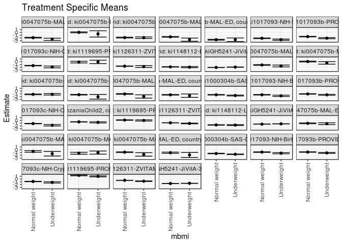

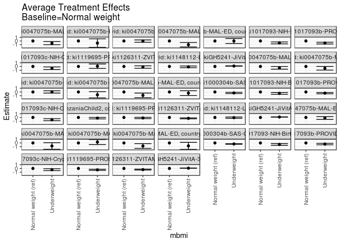

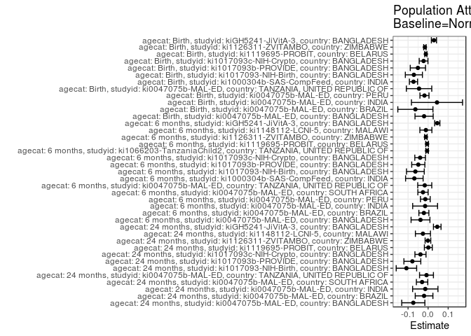

## Results Table

### Parameter: TSM

| agecat | studyid | country | intervention_level | baseline_level | estimate | ci_lower | ci_upper |
| --- | --- | --- | --- | --- | --- | --- | --- |
| Birth | ki0047075b-MAL-ED | BANGLADESH | Normal weight | NA | -1.0577930 | -1.2044438 | -0.9111422 |
| Birth | ki0047075b-MAL-ED | BANGLADESH | Underweight | NA | -1.1964176 | -1.5284595 | -0.8643757 |
| Birth | ki0047075b-MAL-ED | BRAZIL | Normal weight | NA | -0.6249153 | -0.9137560 | -0.3360745 |
| Birth | ki0047075b-MAL-ED | BRAZIL | Underweight | NA | -1.4380000 | -2.2732876 | -0.6027124 |
| Birth | ki0047075b-MAL-ED | INDIA | Normal weight | NA | -1.2745714 | -1.6299983 | -0.9191446 |
| Birth | ki0047075b-MAL-ED | INDIA | Underweight | NA | -1.0362500 | -1.6020040 | -0.4704960 |
| Birth | ki0047075b-MAL-ED | PERU | Normal weight | NA | -0.8869683 | -1.0065725 | -0.7673641 |
| Birth | ki0047075b-MAL-ED | PERU | Underweight | NA | -1.7080000 | -2.3409322 | -1.0750678 |
| Birth | ki0047075b-MAL-ED | TANZANIA, UNITED REPUBLIC OF | Normal weight | NA | -1.0913043 | -1.3056634 | -0.8769453 |
| Birth | ki0047075b-MAL-ED | TANZANIA, UNITED REPUBLIC OF | Underweight | NA | -1.8785714 | -2.8008825 | -0.9562603 |
| Birth | ki1000304b-SAS-CompFeed | INDIA | Normal weight | NA | -1.3709989 | -1.4640712 | -1.2779266 |
| Birth | ki1000304b-SAS-CompFeed | INDIA | Underweight | NA | -1.6461229 | -1.7561055 | -1.5361403 |
| Birth | ki1017093-NIH-Birth | BANGLADESH | Normal weight | NA | -0.8599911 | -0.9557584 | -0.7642237 |
| Birth | ki1017093-NIH-Birth | BANGLADESH | Underweight | NA | -1.2567035 | -1.4770903 | -1.0363167 |
| Birth | ki1017093b-PROVIDE | BANGLADESH | Normal weight | NA | -0.8415759 | -0.9267979 | -0.7563540 |
| Birth | ki1017093b-PROVIDE | BANGLADESH | Underweight | NA | -1.1441818 | -1.3177031 | -0.9706606 |
| Birth | ki1017093c-NIH-Crypto | BANGLADESH | Normal weight | NA | -0.8862922 | -0.9629763 | -0.8096082 |
| Birth | ki1017093c-NIH-Crypto | BANGLADESH | Underweight | NA | -1.2172497 | -1.4495084 | -0.9849910 |
| Birth | ki1119695-PROBIT | BELARUS | Normal weight | NA | 1.3385468 | 1.1787384 | 1.4983551 |
| Birth | ki1119695-PROBIT | BELARUS | Underweight | NA | 0.9639689 | 0.7811889 | 1.1467488 |
| Birth | ki1126311-ZVITAMBO | ZIMBABWE | Normal weight | NA | -0.4604582 | -0.4855325 | -0.4353839 |
| Birth | ki1126311-ZVITAMBO | ZIMBABWE | Underweight | NA | -0.7716599 | -0.8899524 | -0.6533675 |
| Birth | kiGH5241-JiVitA-3 | BANGLADESH | Normal weight | NA | -1.6183721 | -1.6415316 | -1.5952126 |
| Birth | kiGH5241-JiVitA-3 | BANGLADESH | Underweight | NA | -1.5430319 | -1.5711623 | -1.5149016 |
| 6 months | ki0047075b-MAL-ED | BANGLADESH | Normal weight | NA | -1.1670158 | -1.2935694 | -1.0404621 |
| 6 months | ki0047075b-MAL-ED | BANGLADESH | Underweight | NA | -1.5368856 | -1.8619750 | -1.2117961 |
| 6 months | ki0047075b-MAL-ED | BRAZIL | Normal weight | NA | 0.0708375 | -0.0781476 | 0.2198227 |
| 6 months | ki0047075b-MAL-ED | BRAZIL | Underweight | NA | -0.4164815 | -0.8769172 | 0.0439543 |
| 6 months | ki0047075b-MAL-ED | INDIA | Normal weight | NA | -1.1909910 | -1.3241084 | -1.0578737 |
| 6 months | ki0047075b-MAL-ED | INDIA | Underweight | NA | -1.1798655 | -1.4486193 | -0.9111117 |
| 6 months | ki0047075b-MAL-ED | PERU | Normal weight | NA | -1.3101467 | -1.4185443 | -1.2017491 |
| 6 months | ki0047075b-MAL-ED | PERU | Underweight | NA | -2.0693333 | -2.9031517 | -1.2355150 |
| 6 months | ki0047075b-MAL-ED | SOUTH AFRICA | Normal weight | NA | -1.0471625 | -1.1780920 | -0.9162331 |
| 6 months | ki0047075b-MAL-ED | SOUTH AFRICA | Underweight | NA | -1.9571429 | -2.5636947 | -1.3505910 |
| 6 months | ki0047075b-MAL-ED | TANZANIA, UNITED REPUBLIC OF | Normal weight | NA | -1.3519592 | -1.4761814 | -1.2277369 |
| 6 months | ki0047075b-MAL-ED | TANZANIA, UNITED REPUBLIC OF | Underweight | NA | -1.6652448 | -2.2858427 | -1.0446470 |
| 6 months | ki1000304b-SAS-CompFeed | INDIA | Normal weight | NA | -1.3382133 | -1.4388103 | -1.2376163 |
| 6 months | ki1000304b-SAS-CompFeed | INDIA | Underweight | NA | -1.6009100 | -1.7552407 | -1.4465793 |
| 6 months | ki1017093-NIH-Birth | BANGLADESH | Normal weight | NA | -1.3438268 | -1.4394720 | -1.2481815 |
| 6 months | ki1017093-NIH-Birth | BANGLADESH | Underweight | NA | -1.7274911 | -1.9551055 | -1.4998766 |
| 6 months | ki1017093b-PROVIDE | BANGLADESH | Normal weight | NA | -1.0405551 | -1.1241602 | -0.9569500 |
| 6 months | ki1017093b-PROVIDE | BANGLADESH | Underweight | NA | -1.3552185 | -1.5209242 | -1.1895127 |
| 6 months | ki1017093c-NIH-Crypto | BANGLADESH | Normal weight | NA | -1.1588116 | -1.2330294 | -1.0845937 |
| 6 months | ki1017093c-NIH-Crypto | BANGLADESH | Underweight | NA | -1.7628011 | -2.0203385 | -1.5052637 |
| 6 months | ki1066203-TanzaniaChild2 | TANZANIA, UNITED REPUBLIC OF | Normal weight | NA | -0.5355642 | -0.5861364 | -0.4849919 |
| 6 months | ki1066203-TanzaniaChild2 | TANZANIA, UNITED REPUBLIC OF | Underweight | NA | -0.7097182 | -0.9142936 | -0.5051427 |
| 6 months | ki1119695-PROBIT | BELARUS | Normal weight | NA | 0.1203757 | 0.0279635 | 0.2127878 |
| 6 months | ki1119695-PROBIT | BELARUS | Underweight | NA | -0.0149359 | -0.2412626 | 0.2113909 |
| 6 months | ki1126311-ZVITAMBO | ZIMBABWE | Normal weight | NA | -0.8687953 | -0.8969894 | -0.8406012 |
| 6 months | ki1126311-ZVITAMBO | ZIMBABWE | Underweight | NA | -1.1078408 | -1.2288199 | -0.9868617 |
| 6 months | ki1148112-LCNI-5 | MALAWI | Normal weight | NA | -1.6466221 | -1.7248989 | -1.5683452 |
| 6 months | ki1148112-LCNI-5 | MALAWI | Underweight | NA | -1.6991065 | -1.8553156 | -1.5428973 |
| 6 months | kiGH5241-JiVitA-3 | BANGLADESH | Normal weight | NA | -1.3597159 | -1.3865874 | -1.3328443 |
| 6 months | kiGH5241-JiVitA-3 | BANGLADESH | Underweight | NA | -1.2410750 | -1.2717520 | -1.2103981 |
| 24 months | ki0047075b-MAL-ED | BANGLADESH | Normal weight | NA | -1.9045415 | -2.0360642 | -1.7730189 |
| 24 months | ki0047075b-MAL-ED | BANGLADESH | Underweight | NA | -2.4888246 | -2.8938496 | -2.0837997 |
| 24 months | ki0047075b-MAL-ED | BRAZIL | Normal weight | NA | 0.0261008 | -0.1439691 | 0.1961708 |
| 24 months | ki0047075b-MAL-ED | BRAZIL | Underweight | NA | -0.5391667 | -1.6773310 | 0.5989977 |
| 24 months | ki0047075b-MAL-ED | INDIA | Normal weight | NA | -1.8703409 | -2.0112235 | -1.7294583 |
| 24 months | ki0047075b-MAL-ED | INDIA | Underweight | NA | -1.9004685 | -2.1818116 | -1.6191253 |
| 24 months | ki0047075b-MAL-ED | SOUTH AFRICA | Normal weight | NA | -1.6131241 | -1.7506877 | -1.4755605 |
| 24 months | ki0047075b-MAL-ED | SOUTH AFRICA | Underweight | NA | -2.6192857 | -3.1998173 | -2.0387542 |
| 24 months | ki0047075b-MAL-ED | TANZANIA, UNITED REPUBLIC OF | Normal weight | NA | -2.6374664 | -2.7757292 | -2.4992035 |
| 24 months | ki0047075b-MAL-ED | TANZANIA, UNITED REPUBLIC OF | Underweight | NA | -2.6474704 | -3.2970568 | -1.9978839 |
| 24 months | ki1017093-NIH-Birth | BANGLADESH | Normal weight | NA | -2.1108493 | -2.2241279 | -1.9975707 |
| 24 months | ki1017093-NIH-Birth | BANGLADESH | Underweight | NA | -2.6210466 | -2.8508988 | -2.3911944 |
| 24 months | ki1017093b-PROVIDE | BANGLADESH | Normal weight | NA | -1.5216946 | -1.6125874 | -1.4308019 |
| 24 months | ki1017093b-PROVIDE | BANGLADESH | Underweight | NA | -2.0882792 | -2.2979142 | -1.8786441 |
| 24 months | ki1017093c-NIH-Crypto | BANGLADESH | Normal weight | NA | -1.4031348 | -1.4898367 | -1.3164330 |
| 24 months | ki1017093c-NIH-Crypto | BANGLADESH | Underweight | NA | -1.8828465 | -2.2161522 | -1.5495409 |
| 24 months | ki1119695-PROBIT | BELARUS | Normal weight | NA | -0.1332742 | -0.4365564 | 0.1700080 |
| 24 months | ki1119695-PROBIT | BELARUS | Underweight | NA | -0.0596294 | -0.6664107 | 0.5471520 |
| 24 months | ki1126311-ZVITAMBO | ZIMBABWE | Normal weight | NA | -1.5974449 | -1.6610527 | -1.5338370 |
| 24 months | ki1126311-ZVITAMBO | ZIMBABWE | Underweight | NA | -1.7471789 | -2.0693886 | -1.4249691 |
| 24 months | ki1148112-LCNI-5 | MALAWI | Normal weight | NA | -1.8592940 | -1.9487215 | -1.7698664 |
| 24 months | ki1148112-LCNI-5 | MALAWI | Underweight | NA | -1.9600131 | -2.1635188 | -1.7565075 |
| 24 months | kiGH5241-JiVitA-3 | BANGLADESH | Normal weight | NA | -2.0592929 | -2.0933465 | -2.0252392 |
| 24 months | kiGH5241-JiVitA-3 | BANGLADESH | Underweight | NA | -1.9398901 | -1.9800543 | -1.8997258 |

### Parameter: E(Y)

| agecat | studyid | country | intervention_level | baseline_level | estimate | ci_lower | ci_upper |
| --- | --- | --- | --- | --- | --- | --- | --- |
| Birth | ki0047075b-MAL-ED | BANGLADESH | NA | NA | -1.0778829 | -1.2122580 | -0.9435077 |
| Birth | ki0047075b-MAL-ED | BRAZIL | NA | NA | -0.6884375 | -0.9678371 | -0.4090379 |
| Birth | ki0047075b-MAL-ED | INDIA | NA | NA | -1.2302326 | -1.5393614 | -0.9211037 |
| Birth | ki0047075b-MAL-ED | PERU | NA | NA | -0.9051327 | -1.0238686 | -0.7863969 |
| Birth | ki0047075b-MAL-ED | TANZANIA, UNITED REPUBLIC OF | NA | NA | -1.1364754 | -1.3478823 | -0.9250686 |
| Birth | ki1000304b-SAS-CompFeed | INDIA | NA | NA | -1.4438150 | -1.5337502 | -1.3538797 |
| Birth | ki1017093-NIH-Birth | BANGLADESH | NA | NA | -0.9310197 | -1.0197391 | -0.8423003 |
| Birth | ki1017093b-PROVIDE | BANGLADESH | NA | NA | -0.8925145 | -0.9687201 | -0.8163089 |
| Birth | ki1017093c-NIH-Crypto | BANGLADESH | NA | NA | -0.9089163 | -0.9806324 | -0.8372002 |
| Birth | ki1119695-PROBIT | BELARUS | NA | NA | 1.3271449 | 1.1680455 | 1.4862444 |
| Birth | ki1126311-ZVITAMBO | ZIMBABWE | NA | NA | -0.4764413 | -0.5009156 | -0.4519670 |
| Birth | kiGH5241-JiVitA-3 | BANGLADESH | NA | NA | -1.5893196 | -1.6086080 | -1.5700313 |
| 6 months | ki0047075b-MAL-ED | BANGLADESH | NA | NA | -1.2049931 | -1.3222136 | -1.0877726 |
| 6 months | ki0047075b-MAL-ED | BRAZIL | NA | NA | 0.0497516 | -0.0948051 | 0.1943083 |
| 6 months | ki0047075b-MAL-ED | INDIA | NA | NA | -1.2059574 | -1.3243030 | -1.0876119 |
| 6 months | ki0047075b-MAL-ED | PERU | NA | NA | -1.3241023 | -1.4325083 | -1.2156964 |
| 6 months | ki0047075b-MAL-ED | SOUTH AFRICA | NA | NA | -1.0727443 | -1.2024880 | -0.9430006 |
| 6 months | ki0047075b-MAL-ED | TANZANIA, UNITED REPUBLIC OF | NA | NA | -1.3687449 | -1.4907629 | -1.2467270 |
| 6 months | ki1000304b-SAS-CompFeed | INDIA | NA | NA | -1.4068893 | -1.4981242 | -1.3156543 |
| 6 months | ki1017093-NIH-Birth | BANGLADESH | NA | NA | -1.4073821 | -1.4960598 | -1.3187043 |
| 6 months | ki1017093b-PROVIDE | BANGLADESH | NA | NA | -1.0895301 | -1.1639589 | -1.0151013 |
| 6 months | ki1017093c-NIH-Crypto | BANGLADESH | NA | NA | -1.1986783 | -1.2700937 | -1.1272630 |
| 6 months | ki1066203-TanzaniaChild2 | TANZANIA, UNITED REPUBLIC OF | NA | NA | -0.5405711 | -0.5899965 | -0.4911457 |
| 6 months | ki1119695-PROBIT | BELARUS | NA | NA | 0.1153731 | 0.0222128 | 0.2085334 |
| 6 months | ki1126311-ZVITAMBO | ZIMBABWE | NA | NA | -0.8800508 | -0.9074511 | -0.8526506 |
| 6 months | ki1148112-LCNI-5 | MALAWI | NA | NA | -1.6577751 | -1.7275296 | -1.5880207 |
| 6 months | kiGH5241-JiVitA-3 | BANGLADESH | NA | NA | -1.3140048 | -1.3371141 | -1.2908955 |
| 24 months | ki0047075b-MAL-ED | BANGLADESH | NA | NA | -1.9783962 | -2.1050210 | -1.8517715 |
| 24 months | ki0047075b-MAL-ED | BRAZIL | NA | NA | 0.0059127 | -0.1637934 | 0.1756188 |
| 24 months | ki0047075b-MAL-ED | INDIA | NA | NA | -1.8844690 | -2.0097879 | -1.7591502 |
| 24 months | ki0047075b-MAL-ED | SOUTH AFRICA | NA | NA | -1.6432229 | -1.7795844 | -1.5068615 |
| 24 months | ki0047075b-MAL-ED | TANZANIA, UNITED REPUBLIC OF | NA | NA | -2.6455607 | -2.7807256 | -2.5103959 |
| 24 months | ki1017093-NIH-Birth | BANGLADESH | NA | NA | -2.2190579 | -2.3217459 | -2.1163699 |
| 24 months | ki1017093b-PROVIDE | BANGLADESH | NA | NA | -1.6002600 | -1.6836163 | -1.5169036 |
| 24 months | ki1017093c-NIH-Crypto | BANGLADESH | NA | NA | -1.4412646 | -1.5249156 | -1.3576135 |
| 24 months | ki1119695-PROBIT | BELARUS | NA | NA | -0.1322181 | -0.4300523 | 0.1656161 |
| 24 months | ki1126311-ZVITAMBO | ZIMBABWE | NA | NA | -1.5983212 | -1.6605141 | -1.5361283 |
| 24 months | ki1148112-LCNI-5 | MALAWI | NA | NA | -1.8851820 | -1.9664818 | -1.8038822 |
| 24 months | kiGH5241-JiVitA-3 | BANGLADESH | NA | NA | -2.0137632 | -2.0415122 | -1.9860142 |

### Parameter: ATE

| agecat | studyid | country | intervention_level | baseline_level | estimate | ci_lower | ci_upper |
| --- | --- | --- | --- | --- | --- | --- | --- |
| Birth | ki0047075b-MAL-ED | BANGLADESH | Normal weight | Normal weight | 0.0000000 | 0.0000000 | 0.0000000 |
| Birth | ki0047075b-MAL-ED | BANGLADESH | Underweight | Normal weight | -0.1386246 | -0.5029392 | 0.2256900 |
| Birth | ki0047075b-MAL-ED | BRAZIL | Normal weight | Normal weight | 0.0000000 | 0.0000000 | 0.0000000 |
| Birth | ki0047075b-MAL-ED | BRAZIL | Underweight | Normal weight | -0.8130847 | -1.6969028 | 0.0707333 |
| Birth | ki0047075b-MAL-ED | INDIA | Normal weight | Normal weight | 0.0000000 | 0.0000000 | 0.0000000 |
| Birth | ki0047075b-MAL-ED | INDIA | Underweight | Normal weight | 0.2383214 | -0.4298147 | 0.9064576 |
| Birth | ki0047075b-MAL-ED | PERU | Normal weight | Normal weight | 0.0000000 | 0.0000000 | 0.0000000 |
| Birth | ki0047075b-MAL-ED | PERU | Underweight | Normal weight | -0.8210317 | -1.4651655 | -0.1768979 |
| Birth | ki0047075b-MAL-ED | TANZANIA, UNITED REPUBLIC OF | Normal weight | Normal weight | 0.0000000 | 0.0000000 | 0.0000000 |
| Birth | ki0047075b-MAL-ED | TANZANIA, UNITED REPUBLIC OF | Underweight | Normal weight | -0.7872671 | -1.7341607 | 0.1596266 |
| Birth | ki1000304b-SAS-CompFeed | INDIA | Normal weight | Normal weight | 0.0000000 | 0.0000000 | 0.0000000 |
| Birth | ki1000304b-SAS-CompFeed | INDIA | Underweight | Normal weight | -0.2751241 | -0.3552893 | -0.1949588 |
| Birth | ki1017093-NIH-Birth | BANGLADESH | Normal weight | Normal weight | 0.0000000 | 0.0000000 | 0.0000000 |
| Birth | ki1017093-NIH-Birth | BANGLADESH | Underweight | Normal weight | -0.3967125 | -0.6369488 | -0.1564761 |
| Birth | ki1017093b-PROVIDE | BANGLADESH | Normal weight | Normal weight | 0.0000000 | 0.0000000 | 0.0000000 |
| Birth | ki1017093b-PROVIDE | BANGLADESH | Underweight | Normal weight | -0.3026059 | -0.4980875 | -0.1071244 |
| Birth | ki1017093c-NIH-Crypto | BANGLADESH | Normal weight | Normal weight | 0.0000000 | 0.0000000 | 0.0000000 |
| Birth | ki1017093c-NIH-Crypto | BANGLADESH | Underweight | Normal weight | -0.3309575 | -0.5759204 | -0.0859945 |
| Birth | ki1119695-PROBIT | BELARUS | Normal weight | Normal weight | 0.0000000 | 0.0000000 | 0.0000000 |
| Birth | ki1119695-PROBIT | BELARUS | Underweight | Normal weight | -0.3745779 | -0.5220229 | -0.2271329 |
| Birth | ki1126311-ZVITAMBO | ZIMBABWE | Normal weight | Normal weight | 0.0000000 | 0.0000000 | 0.0000000 |
| Birth | ki1126311-ZVITAMBO | ZIMBABWE | Underweight | Normal weight | -0.3112018 | -0.4321368 | -0.1902667 |
| Birth | kiGH5241-JiVitA-3 | BANGLADESH | Normal weight | Normal weight | 0.0000000 | 0.0000000 | 0.0000000 |
| Birth | kiGH5241-JiVitA-3 | BANGLADESH | Underweight | Normal weight | 0.0753401 | 0.0420986 | 0.1085817 |
| 6 months | ki0047075b-MAL-ED | BANGLADESH | Normal weight | Normal weight | 0.0000000 | 0.0000000 | 0.0000000 |
| 6 months | ki0047075b-MAL-ED | BANGLADESH | Underweight | Normal weight | -0.3698698 | -0.7195735 | -0.0201661 |
| 6 months | ki0047075b-MAL-ED | BRAZIL | Normal weight | Normal weight | 0.0000000 | 0.0000000 | 0.0000000 |
| 6 months | ki0047075b-MAL-ED | BRAZIL | Underweight | Normal weight | -0.4873190 | -0.9712587 | -0.0033793 |
| 6 months | ki0047075b-MAL-ED | INDIA | Normal weight | Normal weight | 0.0000000 | 0.0000000 | 0.0000000 |
| 6 months | ki0047075b-MAL-ED | INDIA | Underweight | Normal weight | 0.0111255 | -0.2897296 | 0.3119806 |
| 6 months | ki0047075b-MAL-ED | PERU | Normal weight | Normal weight | 0.0000000 | 0.0000000 | 0.0000000 |
| 6 months | ki0047075b-MAL-ED | PERU | Underweight | Normal weight | -0.7591866 | -1.6000214 | 0.0816481 |
| 6 months | ki0047075b-MAL-ED | SOUTH AFRICA | Normal weight | Normal weight | 0.0000000 | 0.0000000 | 0.0000000 |
| 6 months | ki0047075b-MAL-ED | SOUTH AFRICA | Underweight | Normal weight | -0.9099803 | -1.5305024 | -0.2894583 |
| 6 months | ki0047075b-MAL-ED | TANZANIA, UNITED REPUBLIC OF | Normal weight | Normal weight | 0.0000000 | 0.0000000 | 0.0000000 |
| 6 months | ki0047075b-MAL-ED | TANZANIA, UNITED REPUBLIC OF | Underweight | Normal weight | -0.3132857 | -0.9459900 | 0.3194186 |
| 6 months | ki1000304b-SAS-CompFeed | INDIA | Normal weight | Normal weight | 0.0000000 | 0.0000000 | 0.0000000 |
| 6 months | ki1000304b-SAS-CompFeed | INDIA | Underweight | Normal weight | -0.2626967 | -0.4287118 | -0.0966816 |
| 6 months | ki1017093-NIH-Birth | BANGLADESH | Normal weight | Normal weight | 0.0000000 | 0.0000000 | 0.0000000 |
| 6 months | ki1017093-NIH-Birth | BANGLADESH | Underweight | Normal weight | -0.3836643 | -0.6309820 | -0.1363466 |
| 6 months | ki1017093b-PROVIDE | BANGLADESH | Normal weight | Normal weight | 0.0000000 | 0.0000000 | 0.0000000 |
| 6 months | ki1017093b-PROVIDE | BANGLADESH | Underweight | Normal weight | -0.3146634 | -0.5002038 | -0.1291229 |
| 6 months | ki1017093c-NIH-Crypto | BANGLADESH | Normal weight | Normal weight | 0.0000000 | 0.0000000 | 0.0000000 |
| 6 months | ki1017093c-NIH-Crypto | BANGLADESH | Underweight | Normal weight | -0.6039895 | -0.8730897 | -0.3348894 |
| 6 months | ki1066203-TanzaniaChild2 | TANZANIA, UNITED REPUBLIC OF | Normal weight | Normal weight | 0.0000000 | 0.0000000 | 0.0000000 |
| 6 months | ki1066203-TanzaniaChild2 | TANZANIA, UNITED REPUBLIC OF | Underweight | Normal weight | -0.1741540 | -0.3849018 | 0.0365938 |
| 6 months | ki1119695-PROBIT | BELARUS | Normal weight | Normal weight | 0.0000000 | 0.0000000 | 0.0000000 |
| 6 months | ki1119695-PROBIT | BELARUS | Underweight | Normal weight | -0.1353115 | -0.3245023 | 0.0538793 |
| 6 months | ki1126311-ZVITAMBO | ZIMBABWE | Normal weight | Normal weight | 0.0000000 | 0.0000000 | 0.0000000 |
| 6 months | ki1126311-ZVITAMBO | ZIMBABWE | Underweight | Normal weight | -0.2390454 | -0.3632631 | -0.1148278 |
| 6 months | ki1148112-LCNI-5 | MALAWI | Normal weight | Normal weight | 0.0000000 | 0.0000000 | 0.0000000 |
| 6 months | ki1148112-LCNI-5 | MALAWI | Underweight | Normal weight | -0.0524844 | -0.2272859 | 0.1223171 |
| 6 months | kiGH5241-JiVitA-3 | BANGLADESH | Normal weight | Normal weight | 0.0000000 | 0.0000000 | 0.0000000 |
| 6 months | kiGH5241-JiVitA-3 | BANGLADESH | Underweight | Normal weight | 0.1186408 | 0.0848213 | 0.1524604 |
| 24 months | ki0047075b-MAL-ED | BANGLADESH | Normal weight | Normal weight | 0.0000000 | 0.0000000 | 0.0000000 |
| 24 months | ki0047075b-MAL-ED | BANGLADESH | Underweight | Normal weight | -0.5842831 | -1.0090052 | -0.1595610 |
| 24 months | ki0047075b-MAL-ED | BRAZIL | Normal weight | Normal weight | 0.0000000 | 0.0000000 | 0.0000000 |
| 24 months | ki0047075b-MAL-ED | BRAZIL | Underweight | Normal weight | -0.5652675 | -1.7160680 | 0.5855330 |
| 24 months | ki0047075b-MAL-ED | INDIA | Normal weight | Normal weight | 0.0000000 | 0.0000000 | 0.0000000 |
| 24 months | ki0047075b-MAL-ED | INDIA | Underweight | Normal weight | -0.0301275 | -0.3456759 | 0.2854208 |
| 24 months | ki0047075b-MAL-ED | SOUTH AFRICA | Normal weight | Normal weight | 0.0000000 | 0.0000000 | 0.0000000 |
| 24 months | ki0047075b-MAL-ED | SOUTH AFRICA | Underweight | Normal weight | -1.0061616 | -1.6027692 | -0.4095540 |
| 24 months | ki0047075b-MAL-ED | TANZANIA, UNITED REPUBLIC OF | Normal weight | Normal weight | 0.0000000 | 0.0000000 | 0.0000000 |
| 24 months | ki0047075b-MAL-ED | TANZANIA, UNITED REPUBLIC OF | Underweight | Normal weight | -0.0100040 | -0.6734499 | 0.6534419 |
| 24 months | ki1017093-NIH-Birth | BANGLADESH | Normal weight | Normal weight | 0.0000000 | 0.0000000 | 0.0000000 |
| 24 months | ki1017093-NIH-Birth | BANGLADESH | Underweight | Normal weight | -0.5101974 | -0.7663867 | -0.2540080 |
| 24 months | ki1017093b-PROVIDE | BANGLADESH | Normal weight | Normal weight | 0.0000000 | 0.0000000 | 0.0000000 |
| 24 months | ki1017093b-PROVIDE | BANGLADESH | Underweight | Normal weight | -0.5665845 | -0.7958283 | -0.3373407 |
| 24 months | ki1017093c-NIH-Crypto | BANGLADESH | Normal weight | Normal weight | 0.0000000 | 0.0000000 | 0.0000000 |
| 24 months | ki1017093c-NIH-Crypto | BANGLADESH | Underweight | Normal weight | -0.4797117 | -0.8244615 | -0.1349619 |
| 24 months | ki1119695-PROBIT | BELARUS | Normal weight | Normal weight | 0.0000000 | 0.0000000 | 0.0000000 |
| 24 months | ki1119695-PROBIT | BELARUS | Underweight | Normal weight | 0.0736448 | -0.5189489 | 0.6662386 |
| 24 months | ki1126311-ZVITAMBO | ZIMBABWE | Normal weight | Normal weight | 0.0000000 | 0.0000000 | 0.0000000 |
| 24 months | ki1126311-ZVITAMBO | ZIMBABWE | Underweight | Normal weight | -0.1497340 | -0.4783656 | 0.1788976 |
| 24 months | ki1148112-LCNI-5 | MALAWI | Normal weight | Normal weight | 0.0000000 | 0.0000000 | 0.0000000 |
| 24 months | ki1148112-LCNI-5 | MALAWI | Underweight | Normal weight | -0.1007192 | -0.3239149 | 0.1224766 |
| 24 months | kiGH5241-JiVitA-3 | BANGLADESH | Normal weight | Normal weight | 0.0000000 | 0.0000000 | 0.0000000 |
| 24 months | kiGH5241-JiVitA-3 | BANGLADESH | Underweight | Normal weight | 0.1194028 | 0.0706648 | 0.1681408 |

### Parameter: PAR

| agecat | studyid | country | intervention_level | baseline_level | estimate | ci_lower | ci_upper |
| --- | --- | --- | --- | --- | --- | --- | --- |
| Birth | ki0047075b-MAL-ED | BANGLADESH | Normal weight | NA | -0.0200899 | -0.0654188 | 0.0252390 |
| Birth | ki0047075b-MAL-ED | BRAZIL | Normal weight | NA | -0.0635222 | -0.1511062 | 0.0240617 |
| Birth | ki0047075b-MAL-ED | INDIA | Normal weight | NA | 0.0443389 | -0.0830905 | 0.1717683 |
| Birth | ki0047075b-MAL-ED | PERU | Normal weight | NA | -0.0181644 | -0.0407101 | 0.0043812 |
| Birth | ki0047075b-MAL-ED | TANZANIA, UNITED REPUBLIC OF | Normal weight | NA | -0.0451711 | -0.1085427 | 0.0182006 |
| Birth | ki1000304b-SAS-CompFeed | INDIA | Normal weight | NA | -0.0728161 | -0.0931183 | -0.0525139 |
| Birth | ki1017093-NIH-Birth | BANGLADESH | Normal weight | NA | -0.0710287 | -0.1136412 | -0.0284162 |
| Birth | ki1017093b-PROVIDE | BANGLADESH | Normal weight | NA | -0.0509386 | -0.0890039 | -0.0128732 |
| Birth | ki1017093c-NIH-Crypto | BANGLADESH | Normal weight | NA | -0.0226241 | -0.0444018 | -0.0008464 |
| Birth | ki1119695-PROBIT | BELARUS | Normal weight | NA | -0.0114018 | -0.0167373 | -0.0060663 |
| Birth | ki1126311-ZVITAMBO | ZIMBABWE | Normal weight | NA | -0.0159831 | -0.0220748 | -0.0098914 |
| Birth | kiGH5241-JiVitA-3 | BANGLADESH | Normal weight | NA | 0.0290525 | 0.0161956 | 0.0419094 |
| 6 months | ki0047075b-MAL-ED | BANGLADESH | Normal weight | NA | -0.0379773 | -0.0849957 | 0.0090410 |
| 6 months | ki0047075b-MAL-ED | BRAZIL | Normal weight | NA | -0.0210859 | -0.0460040 | 0.0038322 |
| 6 months | ki0047075b-MAL-ED | INDIA | Normal weight | NA | -0.0149664 | -0.0769869 | 0.0470541 |
| 6 months | ki0047075b-MAL-ED | PERU | Normal weight | NA | -0.0139556 | -0.0382312 | 0.0103199 |
| 6 months | ki0047075b-MAL-ED | SOUTH AFRICA | Normal weight | NA | -0.0255818 | -0.0511699 | 0.0000064 |
| 6 months | ki0047075b-MAL-ED | TANZANIA, UNITED REPUBLIC OF | Normal weight | NA | -0.0167858 | -0.0517876 | 0.0182161 |
| 6 months | ki1000304b-SAS-CompFeed | INDIA | Normal weight | NA | -0.0686760 | -0.1123592 | -0.0249927 |
| 6 months | ki1017093-NIH-Birth | BANGLADESH | Normal weight | NA | -0.0635553 | -0.1077921 | -0.0193184 |
| 6 months | ki1017093b-PROVIDE | BANGLADESH | Normal weight | NA | -0.0489750 | -0.0817249 | -0.0162251 |
| 6 months | ki1017093c-NIH-Crypto | BANGLADESH | Normal weight | NA | -0.0398668 | -0.0663882 | -0.0133453 |
| 6 months | ki1066203-TanzaniaChild2 | TANZANIA, UNITED REPUBLIC OF | Normal weight | NA | -0.0050069 | -0.0115940 | 0.0015801 |
| 6 months | ki1119695-PROBIT | BELARUS | Normal weight | NA | -0.0050026 | -0.0118955 | 0.0018903 |
| 6 months | ki1126311-ZVITAMBO | ZIMBABWE | Normal weight | NA | -0.0112555 | -0.0174983 | -0.0050127 |
| 6 months | ki1148112-LCNI-5 | MALAWI | Normal weight | NA | -0.0111530 | -0.0411284 | 0.0188223 |
| 6 months | kiGH5241-JiVitA-3 | BANGLADESH | Normal weight | NA | 0.0457111 | 0.0326974 | 0.0587248 |
| 24 months | ki0047075b-MAL-ED | BANGLADESH | Normal weight | NA | -0.0738547 | -0.1315534 | -0.0161560 |
| 24 months | ki0047075b-MAL-ED | BRAZIL | Normal weight | NA | -0.0201881 | -0.0642601 | 0.0238838 |
| 24 months | ki0047075b-MAL-ED | INDIA | Normal weight | NA | -0.0141281 | -0.0772893 | 0.0490331 |
| 24 months | ki0047075b-MAL-ED | SOUTH AFRICA | Normal weight | NA | -0.0300989 | -0.0584341 | -0.0017637 |
| 24 months | ki0047075b-MAL-ED | TANZANIA, UNITED REPUBLIC OF | Normal weight | NA | -0.0080944 | -0.0426670 | 0.0264783 |
| 24 months | ki1017093-NIH-Birth | BANGLADESH | Normal weight | NA | -0.1082086 | -0.1591850 | -0.0572323 |
| 24 months | ki1017093b-PROVIDE | BANGLADESH | Normal weight | NA | -0.0785653 | -0.1206460 | -0.0364847 |
| 24 months | ki1017093c-NIH-Crypto | BANGLADESH | Normal weight | NA | -0.0381297 | -0.0657733 | -0.0104861 |
| 24 months | ki1119695-PROBIT | BELARUS | Normal weight | NA | 0.0010561 | -0.0186304 | 0.0207426 |
| 24 months | ki1126311-ZVITAMBO | ZIMBABWE | Normal weight | NA | -0.0008763 | -0.0149661 | 0.0132135 |
| 24 months | ki1148112-LCNI-5 | MALAWI | Normal weight | NA | -0.0258880 | -0.0634042 | 0.0116281 |
| 24 months | kiGH5241-JiVitA-3 | BANGLADESH | Normal weight | NA | 0.0455297 | 0.0266223 | 0.0644370 |